# Golub experiment

2026-01-22

## Résumé

L’**analyse de Golub (1999)** est un jalon historique en bioinformatique et en oncologie génomique. Publiée dans *Science*, cette étude a prouvé pour la première fois que l’on pouvait classer des cancers sans connaissance biologique préalable, uniquement en utilisant le **profil d’expression des gènes** (transcriptomique).

## Contexte

### 1. Le Problème : AML vs ALL

Avant cette étude, la distinction entre les deux types de leucémies aiguës était basée sur la morphologie des cellules, ce qui est parfois subjectif et sujet à erreur :

- **ALL** (Acute Lymphoblastic Leukemia) : Leucémie aiguë lymphoblastique.
- **AML** (Acute Myeloid Leukemia) : Leucémie aiguë myéloïde.

L’objectif de Golub était de savoir si les puces à ADN (microarrays) pouvaient automatiser ce diagnostic.

### 2. La Méthodologie

L’équipe a utilisé des échantillons de moelle osseuse (38 pour l’entraînement, 34 pour le test) et mesuré l’expression de **6 817 gènes**. L’analyse s’est divisée en deux approches :

#### A. Découverte de classes (Clustering non supervisé)

Ils ont utilisé des **cartes auto-organisatrices (Self-Organizing Maps - SOM)** pour voir si les données se regroupaient naturellement.

- **Résultat :** Les algorithmes ont séparé spontanément les échantillons en deux groupes correspondant presque parfaitement à ALL et AML, prouvant que la signature moléculaire est distincte.

#### B. Prédiction de classes (Apprentissage supervisé)

Ils ont cherché à identifier les “gènes informatifs” (les plus discriminants).

- **Sélection des gènes :** Ils ont choisi les 50 gènes présentant la plus forte corrélation avec la distinction ALL/AML.
- **Weighted Voting (Vote pondéré) :** Un algorithme a été créé pour que chaque gène “vote” pour une classe. La force du vote dépend de l’écart d’expression par rapport à la moyenne.

### 3. Résultats et Impact

- **Précision :** Le modèle a classé correctement 36 des 38 échantillons de l’ensemble d’entraînement et a été validé avec succès sur l’ensemble de test indépendant.
- **Signature moléculaire :** L’étude a identifié des gènes clés comme la *Myéloperoxydase* (marqueur de l’AML).
- **Révolution médicale :** Cela a ouvert la voie à la **médecine de précision**. On ne traite plus seulement un organe, mais une signature génétique.

## Lecture des mesures et exploration

```r
load("00_data/leukemia_data_Golub99_3051.rda")
X <- golub_train_3051
dim( X )
```

```
## [1]   38 3051
```

```r
Y <- golub_train_response
length( Y )
```

```
## [1] 38
```

Chargement des fonctions.

```r
source( "1_backend.R" )
```

Apercu des donnees.

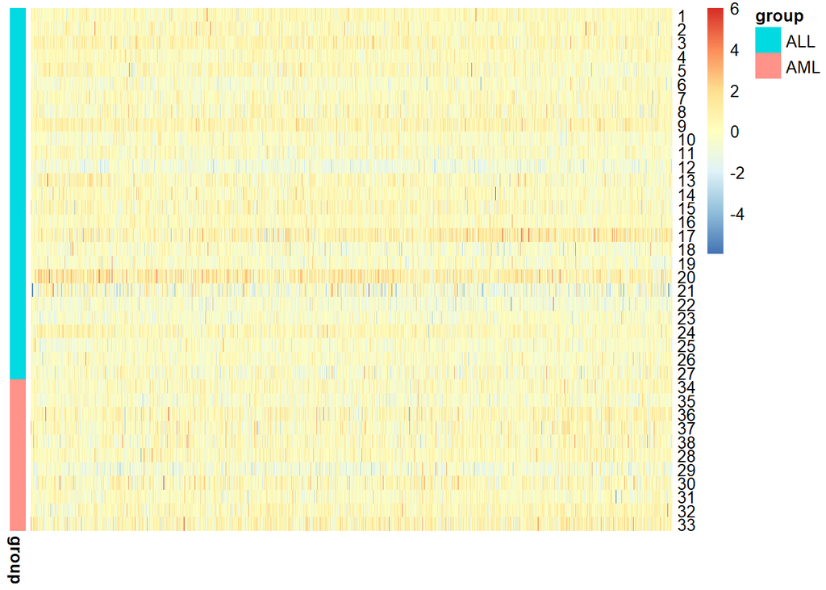

```r
annot <- data.frame( group = Y, row.names = rownames( X ) )
plot_heatmap( X, annotation_row = annot )
```

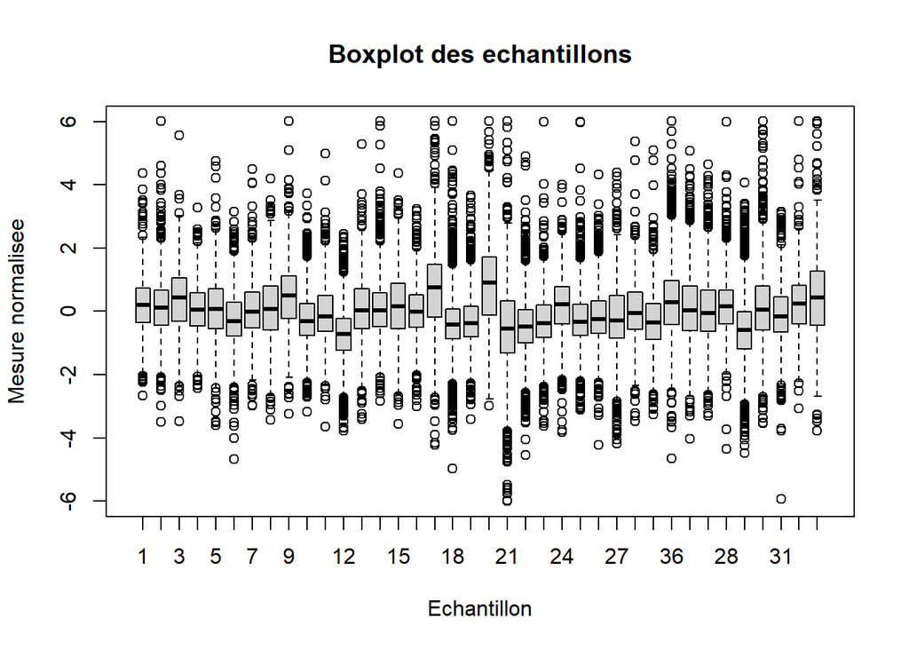

```r
boxplot(
  t(X), xlab = "Echantillon", ylab = "Mesure normalisee",
  main = "Boxplot des echantillons" )
```

## Balayage par t-test et selection

Histogramme des p-values.

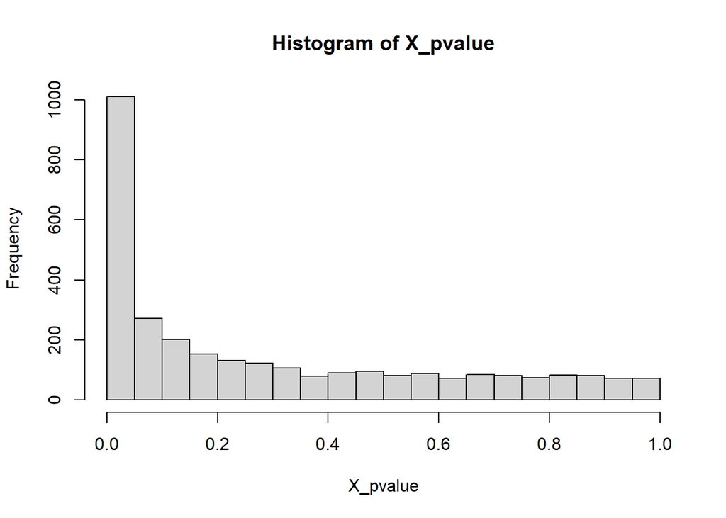

```r
X_pvalue <- calc_pvalue( X, Y )
hist( X_pvalue, breaks = 20 )
```

Selection des variables les plus discrimantes.

```r
oo <- order( X_pvalue )[1:15]
toptable <- data.frame(
  var = colnames(X)[oo],
  p_value = X_pvalue[oo],
  p_value_bonferroni = X_pvalue[oo] * ncol( X )
)
knitr::kable( toptable )
```

|  | var | p_value | p_value_bonferroni |
| --- | --- | --- | --- |
| X95735_at | X95735_at | 0e+00 | 0.0000004 |
| M55150_at | M55150_at | 0e+00 | 0.0000085 |
| Y12670_at | Y12670_at | 0e+00 | 0.0001067 |
| U50136_rna1_at | U50136_rna1_at | 0e+00 | 0.0001517 |
| M31523_at | M31523_at | 0e+00 | 0.0001521 |
| U82759_at | U82759_at | 1e-07 | 0.0003080 |
| M27891_at | M27891_at | 1e-07 | 0.0003158 |
| X04085_rna1_at | X04085_rna1_at | 2e-07 | 0.0004879 |
| U22376_cds2_s_at | U22376_cds2_s_at | 2e-07 | 0.0005669 |
| X74262_at | X74262_at | 2e-07 | 0.0006453 |
| Z15115_at | Z15115_at | 3e-07 | 0.0008629 |
| L09209_s_at | L09209_s_at | 3e-07 | 0.0009036 |
| S50223_at | S50223_at | 4e-07 | 0.0011235 |
| U05259_rna1_at | U05259_rna1_at | 4e-07 | 0.0011289 |
| M16038_at | M16038_at | 4e-07 | 0.0012658 |

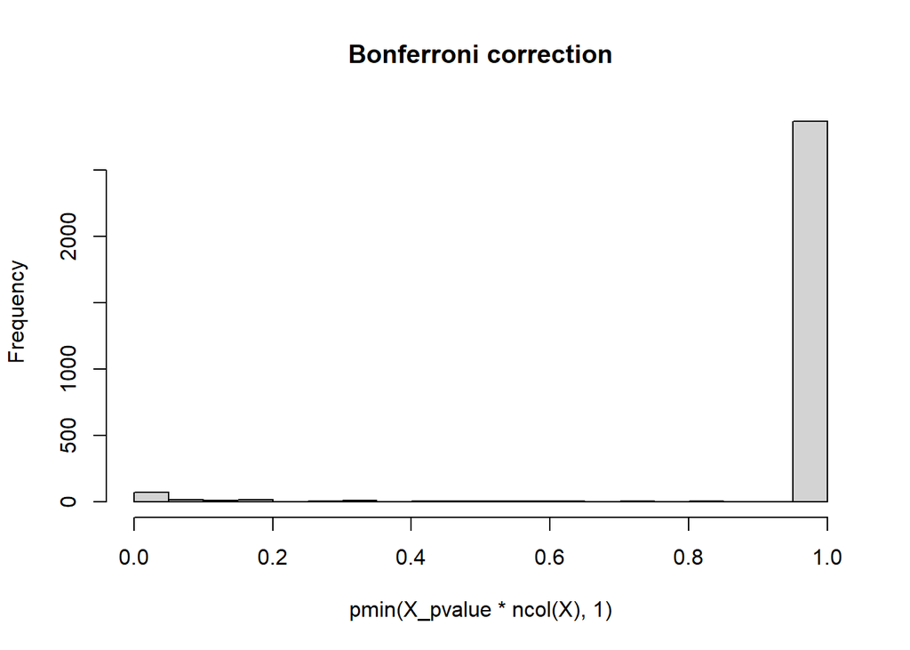

```r
# histogramme avec correction de Bonferroni
hist( pmin( X_pvalue * ncol( X ), 1 ), breaks = 20,
      main = "Bonferroni correction")
```

## Clustering & Heatmap

L’ensemble des mesures.

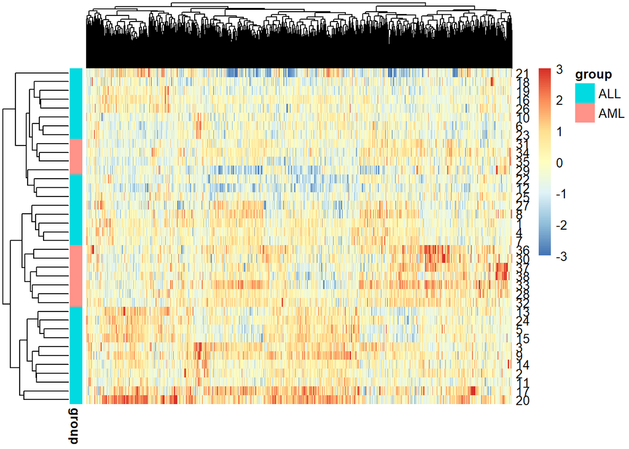

```r
pheatmap::pheatmap(
  X, annotation_row = annot, show_colnames = FALSE, breaks = seq(-3, +3, len = 101)
)
```

Le top des mesures.

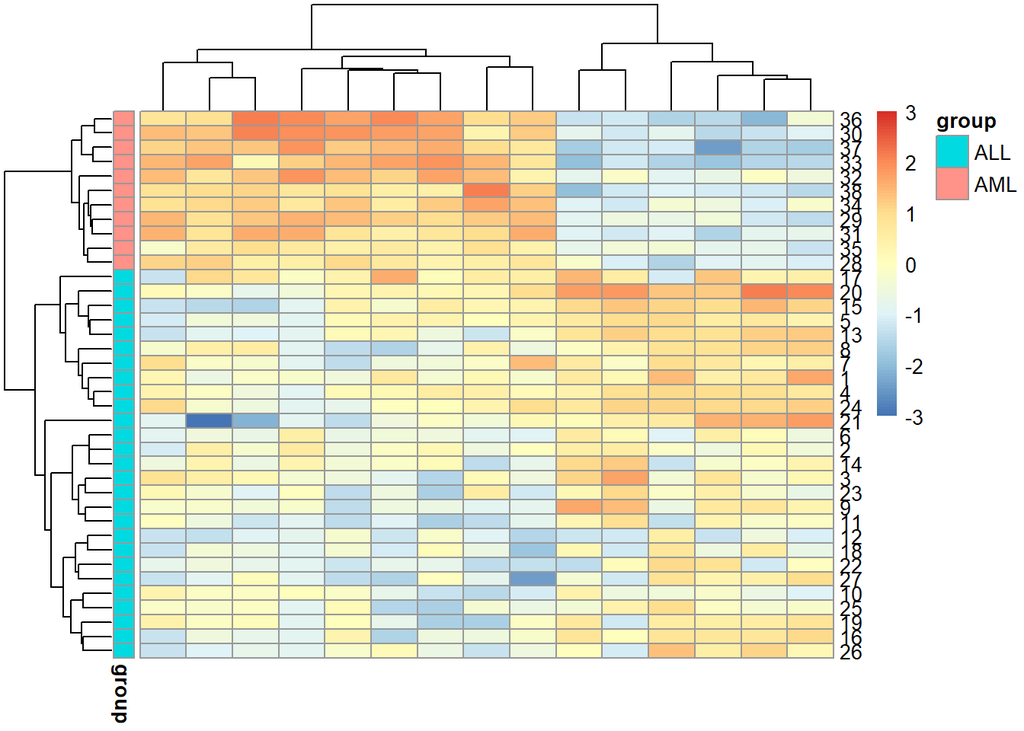

```r
pheatmap::pheatmap(
  X[, oo], annotation_row = annot, show_colnames = FALSE, breaks = seq(-3, +3, len = 101)
)
```

## Reduction de dimension

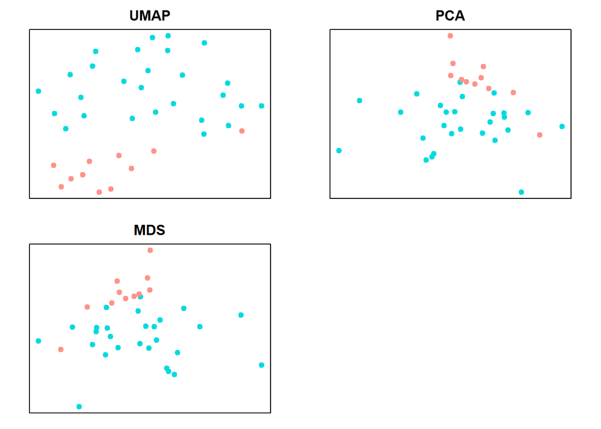

```r
cols <- c( "#00DAE0", "#FF9289" )
opar <- par( no.readonly = TRUE )
par( mfrow = c( 2, 2 ), mar = c( 1, 2, 2, 2) + 0.1, xaxt = "n", yaxt = "n")
# install.packages("uwot")
set.seed( 42 )
xy <- uwot::umap( X )
plot( xy, col = cols[Y], pch = 19, main = "UMAP", xlab = "", ylab = "" )

xy <- prcomp(X)
# biplot(xy, var.axes = F)
plot(xy$x[,1:2], col = cols[Y], pch = 19, main = "PCA", xlab = "", ylab = "" )

plot( cmdscale(dist(X)), col = cols[Y], pch = 19, main = "MDS", xlab = "", ylab = "" )

par( opar )
```